# Automated trading to predict Bitcoin

Arturo Bernal

In this example I predict Bitcoin, applying the same codes we use in the Automated trading subject.

## Data preparation

```r
ticker<-"BTC-USD"
# To get the prices from yahoo finance
getSymbols(ticker,warnings = F,from="2015-11-10",to="2021-11-15")
```

[output not shown]

```
## [1] "BTC-USD"
```

```r
# Get close prices
data<-get("BTC-USD")[,4]
colnames(data)<-"Bit"
data<-na.omit(data)
```

## Variable creation

The next code create some independent variables, for 2 lags.

```r
lagn<-2
avg<-SMA(data[,1],lagn) # var1
std<- rollapply(data[,1],lagn,sd) # var2
macd<- MACD(data[,1],lagn,lagn*2,lagn,"SMA") # var2
rsi<-  RSI(data[,1],lagn,"SMA")# var3

data2<-cbind(data,avg,std,macd,rsi)
```

The next code has the function, that is the Activity 2. The code is hiden until you submit the activity.

The function has a “Loop For” inside that creates many more independent variables. It create the independent variables changing only the variable lagn. In the previous chunk, lagn has the value of 2, and generates, 5 independent variables, and store all of them in the object data2. The Loop makes the variable lagn takes values from k to j, and store all of them in an object. For example, from k=2 to j=3, would generate 10 independent variables. From k=2 to j=4, would generate 15 independent variables, or k=3 to j=4 would generate 10 independent variables, and so on.

The function has 3 arguments, the data (a dataframe) to apply the function and the initial, and variables k and j.

The next code applies the function indep to data,for k=2 and j=28

```r
data2<-indep(data,2,28)
data2<-na.omit(data2)
```

## Sub samples

This code automate the sibsample creation

```r
#The next code make a sub-sample of training and test data sets
di<-dim(data2)

# this code generates a dates for the test dataset
firstt<-index(data2)[di[1]]-30 # date of the 30 days before the last  known price

lastt<-index(data2)[di[1]] # Date of the last  known price

#This is the test data set.
test<-subset(data2,
  +index(data2)>=firstt &
  +index(data2)<=lastt)

# Finally, we make the subset of the training data set. Fist I define "n", as day and "m", as months.
n<-30 # days
m<-5 # months


# This code generates a date of the initial date of the training data set, the final ate is the initial date of the test less 1 day.
trainfin<-firstt -1

# The initial date, is, for this example,   "n"*m months before the final date of the training data set.
trainini<-trainfin-n*m


# The subset of the training data set.
train<-subset(data2,
  +index(data2)>=trainini &
  +index(data2)<=trainfin)
```

## Making the model

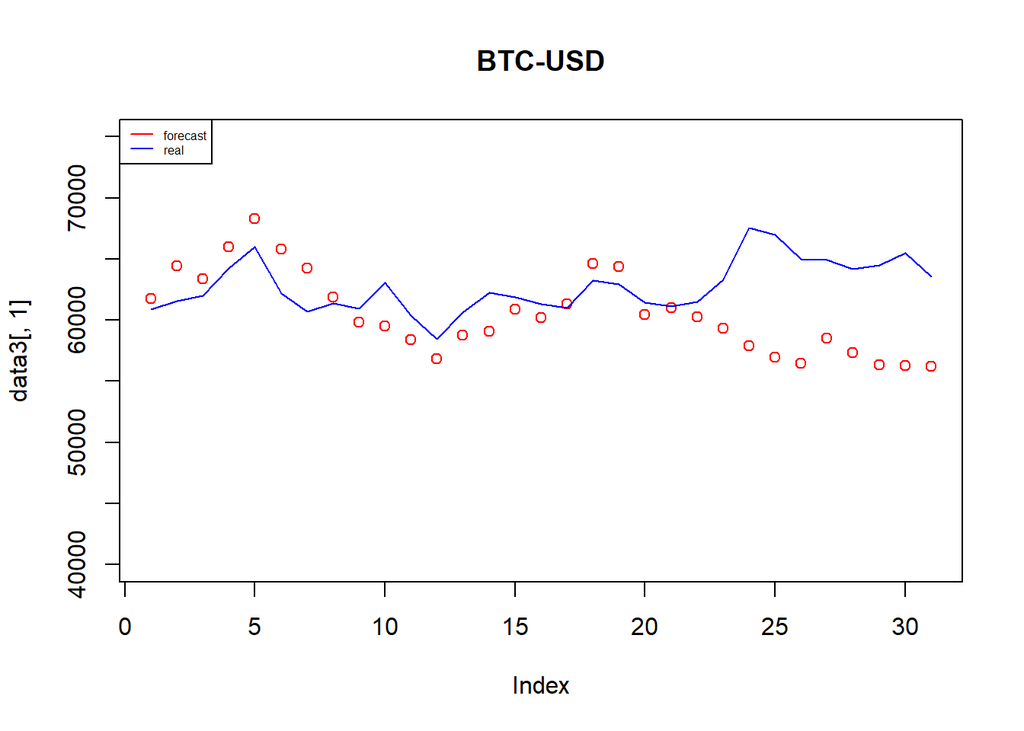

```r
# This code makes the model on the train data set.
model<-lm(Bit~.,data=train)

# This code apply the step function, to select the independent variables that fits better to the model, to make a prediction. The direction="both", makes forward and backward method at the same time.
modelstep <- step(model, direction = "both",trace = F)

# The prediction on the independent variables
pred<-predict(modelstep,test)

# To verify graphically, we use a plot
data3<-as.data.frame(pred)
data3<-cbind(data3,test[,1])
colnames(data3)<-c("Prediction","Real data")
plot(data3[,1],main=ticker,col="red",ylim=c(40000,75000))
lines(data3[,2],col="blue") # Data that raally happends
legend(x= "topleft", legend = c("forecast","real"),lty = 1,col=c("red","blue"),cex=0.5)
```

## Real prediction

Once we train the model and get adequate accuracy, we make use of the model to make the prediction.

```r
firstt<-index(data2)[di[1]]-30
lastt<-index(data2)[di[1]]

testdepr<-subset(data2,
  +index(data2)>=firstt &
  +index(data2)<=lastt)
le<-dim(testdepr)[1]

trainfi<-lastt-30*5
trainr<-subset(data2,
  +index(data2)>=trainfi &
  +index(data2)<=lastt)
```

```r
model<-lm(Bit~.,data=trainr)
modelstep <- step(model, direction = "both",trace = F)
#summary(modelstep)
predf<-predict(modelstep,testdepr)
data3<-as.data.frame(pred)
le<-length(predf)
```

The next code creates the labels of the dates that we are forecasting (remember that our object predicted has the same dates as the test data set).

The function xst, transfors the predicted object into xts, and the order.by would be the index of the object (the sequence of dates, in this case).

```r
dat <- xts(x = data3,
           order.by = seq(lastt,
                          length = le,
                          by = "days"),
           hayek_bday = as.POSIXct("1899-05-08"))
dat
```

```
##                pred
## 2021-11-15 61734.55
## 2021-11-16 64421.26
## 2021-11-17 63372.04
## 2021-11-18 66016.80
## 2021-11-19 68294.47
## 2021-11-20 65807.55
## 2021-11-21 64256.43
## 2021-11-22 61878.64
## 2021-11-23 59803.36
## 2021-11-24 59499.07
## 2021-11-25 58389.95
## 2021-11-26 56820.53
## 2021-11-27 58777.17
## 2021-11-28 59102.33
## 2021-11-29 60896.03
## 2021-11-30 60206.20
## 2021-12-01 61349.10
## 2021-12-02 64644.99
## 2021-12-03 64373.64
## 2021-12-04 60476.64
## 2021-12-05 60991.83
## 2021-12-06 60277.00
## 2021-12-07 59303.56
## 2021-12-08 57894.68
## 2021-12-09 56977.15
## 2021-12-10 56456.29
## 2021-12-11 58538.43
## 2021-12-12 57355.69
## 2021-12-13 56350.47
## 2021-12-14 56288.19
## 2021-12-15 56225.13
```

Finally, aplot of the prediction

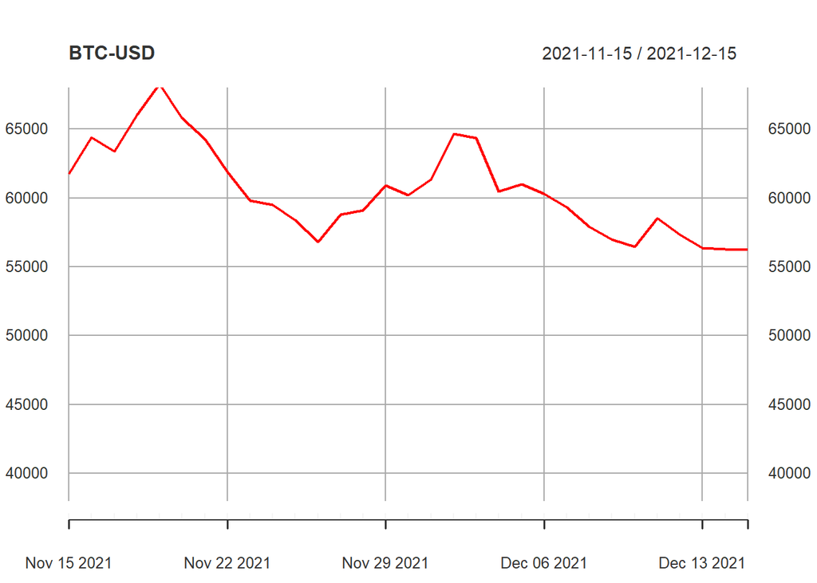

```r
plot(dat[,1],main=ticker,type="l",col="red",ylim=c(38000,68000))
legend(x= "topleft", legend = c("forecast"),lty = 1,col=c("blue"),cex=0.5)
```